# 캐글_코리아 타이타닉 생존자 예측하기

- [참고블로그](https://kaggle-kr.tistory.com/18?category=868316)
  - survival : 생존유무, (0 : 사망, 1 : 생존)
  - pclass : 티켓 등급 ( 1 : 1st, 2 : 2nd, 3 : 3rd)
  - sex : 성별
  - age : 나이
  - sibsp : 함께 탑승한 형제자매, 배우자 수 총합
  - parch : 함께 탑승한 부모, 자녀 수 총합
  - ticket : 티켓 넘버
  - fare : 탑승요금
  - cabin : 객실 번호
  - embarked : 탑승 항구

```python
import pandas as pd
import numpy as np
import seaborn as sns
import matplotlib.pyplot as plt
%matplotlib inline
```

## 0. 데이터 불러오기

```python
path = r'C:\Users\709-000\Desktop\2019-1st-ml-month-with-kakr'
```

```python
train = pd.read_csv(path+'/train.csv', encoding='euc-kr', index_col=None)
test = pd.read_csv(path+'/test.csv', encoding='euc-kr', index_col=None)
```

```python
train.head(3) # 데이터 확인
```

|  | PassengerId | Survived | Pclass | Name | Sex | Age | SibSp | Parch | Ticket | Fare | Cabin | Embarked |
| --- | --- | --- | --- | --- | --- | --- | --- | --- | --- | --- | --- | --- |
| 0 | 1 | 0 | 3 | Braund, Mr. Owen Harris | male | 22.0 | 1 | 0 | A/5 21171 | 7.2500 | NaN | S |
| 1 | 2 | 1 | 1 | Cumings, Mrs. John Bradley (Florence Briggs Th... | female | 38.0 | 1 | 0 | PC 17599 | 71.2833 | C85 | C |
| 2 | 3 | 1 | 3 | Heikkinen, Miss. Laina | female | 26.0 | 0 | 0 | STON/O2. 3101282 | 7.9250 | NaN | S |

```python
print(train.info()) # 데이터 갯수, 데이터 타입 확인
print(test.info())
```

[output not shown]

```python
train.iloc[:, 4:].describe() # 수치형 데이터의 기초통계 확인
```

|  | Age | SibSp | Parch | Fare |
| --- | --- | --- | --- | --- |
| count | 714.000000 | 891.000000 | 891.000000 | 891.000000 |
| mean | 29.699118 | 0.523008 | 0.381594 | 32.204208 |
| std | 14.526497 | 1.102743 | 0.806057 | 49.693429 |
| min | 0.420000 | 0.000000 | 0.000000 | 0.000000 |
| 25% | 20.125000 | 0.000000 | 0.000000 | 7.910400 |
| 50% | 28.000000 | 0.000000 | 0.000000 | 14.454200 |
| 75% | 38.000000 | 1.000000 | 0.000000 | 31.000000 |
| max | 80.000000 | 8.000000 | 6.000000 | 512.329200 |

- 타이타닉 탑승자의 평균 나이는 29.6세, 가장 어린 나이는 0.4, 최고령자는 80세
- 함께 탑승한 형제자매, 배우자 수는 최소 0 ~ 최대 8명
- 함께 탑승한 부모, 자녀 수는 최소 0 ~ 최대 6명
- 평균 탑승 요금은 32.2, 최대 512

## 1. 결측치 확인

```python
train.isnull().sum() # 결측치 확인
```

```
PassengerId      0
Survived         0
Pclass           0
Name             0
Sex              0
Age            177
SibSp            0
Parch            0
Ticket           0
Fare             0
Cabin          687
Embarked         2
dtype: int64
```

```python
test.isnull().sum() # 결측치 확인
```

```
PassengerId      0
Pclass           0
Name             0
Sex              0
Age             86
SibSp            0
Parch            0
Ticket           0
Fare             1
Cabin          327
Embarked         0
dtype: int64
```

- train, test 모두 age, cabin에서 결측치 확인됨

## 2. 타겟 변수 확인

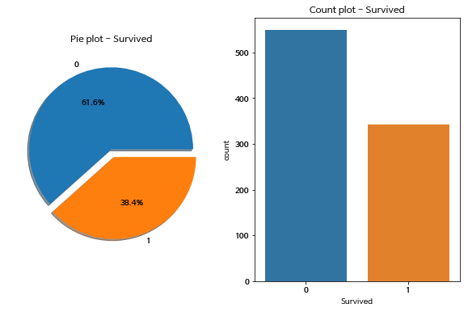

```python
f, ax = plt.subplots(1, 2, figsize=(10, 6))

train['Survived'].value_counts().plot.pie(explode=[0, 0.1], autopct='%1.1f%%', ax=ax[0], shadow=True)
ax[0].set_title('Pie plot - Survived')
ax[0].set_ylabel('')
sns.countplot('Survived', data=train, ax=ax[1])
ax[1].set_title('Count plot - Survived')

plt.show()
```

- 사망한 인원이 549명(61%), 생존인원이 342명(38.4%)으로 확인됨

## 3. 탐색적 데이터 분석(EDA)

### 3.1) pclass

- pclass는 이산형 데이터이면서 순서가 있는 데이터
- pclass에 따른 생존율 차이가 있는가?

```python
p1 = train[['Pclass', 'Survived']].groupby(['Pclass']).count() # pclass별 전체 인원 수
```

```python
p2 = train[['Pclass', 'Survived']].groupby(['Pclass']).sum() # pclass별 생존자 수
```

[output not shown]

[figure not shown]

```python
p = t2 / t1 # pcalss별 생존율
print(p)
print(p.plot.bar())
```

- pclass가 좋을수록 생존율이 높은 것을 확인할 수 있으며
- 생존에 pclass가 영향을 미친다고 생각할 수 있다. 따라서 해당 변수를 모델에 포함한다

### 3.2) Sex

- 성별에 따라 생존율의 차이가 있는가

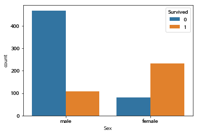

```python
sns.countplot('Sex', hue='Survived', data=train)
```

- 남성보다 여성의 생존율이 높다.
- pcalss와 마찬가지로 모델에 포함한다.

### 3.3) pclass - sex

- pclass와 sex에 따라서 생존율의 차이가 있는가

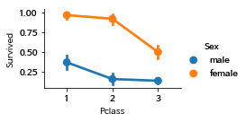

```python
sns.factorplot('Pclass', 'Survived', hue='Sex', data=train, size=2, aspect=1.5)
```

- 모든 pclass에서 여성의 생존율이 높다
- 또한 남자, 여자 모두 pclass가 높을수록 생존율이 높은것을 확인할 수 있다.

### 3.4) age

- survived에 따른 나이는 분포는 어떤가
- pclass - survived에 따른 나이 분포는?

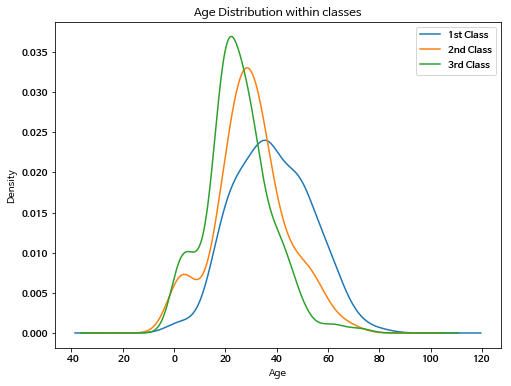

```python
# Age distribution withing classes
plt.figure(figsize=(8, 6))
train['Age'][train['Pclass'] == 1].plot(kind='kde')
train['Age'][train['Pclass'] == 2].plot(kind='kde')
train['Age'][train['Pclass'] == 3].plot(kind='kde')

plt.xlabel('Age')
plt.title('Age Distribution within classes')
plt.legend(['1st Class', '2nd Class', '3rd Class'])
```

### 3.5 pclass - sex - age 모두에 대해 살펴보자

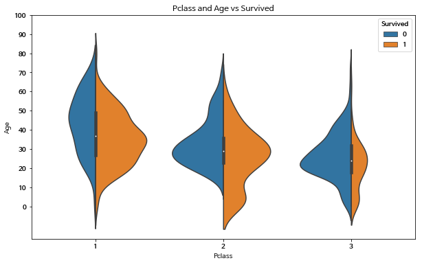

```python
f, ax=plt.subplots(figsize=(10,6))
sns.violinplot("Pclass","Age", hue="Survived", data=train, scale='count', split=True)
ax.set_title('Pclass and Age vs Survived')
ax.set_yticks(range(0,110,10))
plt.show()
```

- 먼저 pcalss - age별 생존여부를 보면,모든 등급에서 나이가 어린사람들이 생존을 많이 한 것을 볼 수 있다. 특히 2등급의 어린 아이들이 많이 구조되었다는 것을 볼 수 있다.

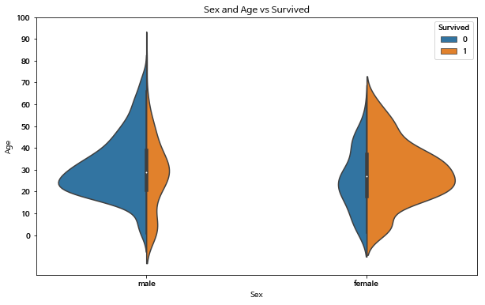

```python
f, ax=plt.subplots(figsize=(10,6))
sns.violinplot("Sex","Age", hue="Survived", data=train, scale='count', split=True)
ax.set_title('Sex and Age vs Survived')
ax.set_yticks(range(0,110,10))
plt.show()
```

- 성별에 따라보면, 확실히 여성이 많이 생존한 것을 볼 수 있다.
- 즉 여성과 아이에게 삶을 양보한 것을 볼 수 있다..

### 3.6) Embarked

- 탑승한 항구에 따라 생존율의 차이가 있는가

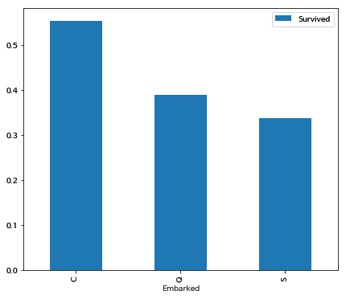

```python
f, ax = plt.subplots(1, 1, figsize=(7, 6))
train[['Embarked', 'Survived']].groupby(['Embarked'], as_index=True).mean().sort_values(by='Survived', ascending=False).plot.bar(ax=ax)
```

- 탑승 항구별 생존율을 보면, C가 가장 높게 나타나고, Q, S순으로 나타난다.

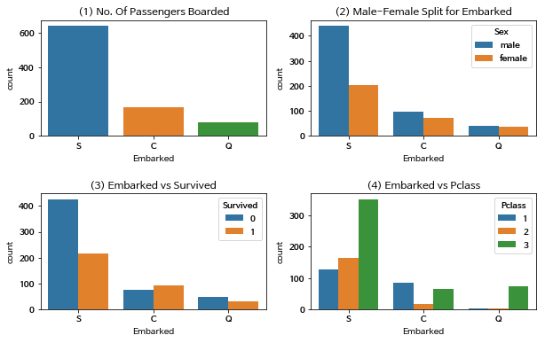

```python
f,ax=plt.subplots(2, 2, figsize=(10,6))

sns.countplot('Embarked', data=train, ax=ax[0,0])
ax[0,0].set_title('(1) No. Of Passengers Boarded') # 탑승항구별 인원 수

sns.countplot('Embarked', hue='Sex', data=train, ax=ax[0,1]) # 탑승항구별 성별 인원 수
ax[0,1].set_title('(2) Male-Female Split for Embarked')

sns.countplot('Embarked', hue='Survived', data=train, ax=ax[1,0]) # 탑승항구별 생존여부별 인원 수
ax[1,0].set_title('(3) Embarked vs Survived')

sns.countplot('Embarked', hue='Pclass', data=train, ax=ax[1,1]) # 탑승항구별 티켓등급별 인원 수
ax[1,1].set_title('(4) Embarked vs Pclass')

plt.subplots_adjust(wspace=0.2, hspace=0.5)
plt.show()
```

- (1) : 탑승 항구별 인원수를 보면 S항구에서 가장 많은 사람이 탑승했다.
- (2) : C, Q는 남녀의 비율이 비슷하지만, S의 경우 남자가 더 많이 탑승했다.
- (3) : S항구의 사망자수가 크게 높다. 아무래도 남자가 많이 탑승했기때문에 그런것으로 보인다.
- (4) : S항구에서 세 티켓등급 모두 많이 합승했으며, C항구에서는 1, 3등급, Q항구에서는 3등급의 인원이 탑승했다.
- S항구에서는 티켓등급 3등급 인원이 가장 많았으며, 남성이 많이 탑승했다.
- 이 변수 또한 모델에 포함하는것이 적절해 보인다.

### 3.7) 파생변수 생성 : Family = Sibsp + parch

- sibsp와 parch를 합하면 family가 된다.
- 이 경우 예측성능이 더 좋아질지 나빠질지 가늠하지는 못하지만, 일단 진행해 본다.
- family와 생존의 관계를 살펴보자.

```python
train['FamilySize'] = train['SibSp'] + train['Parch'] + 1 # 자신을 포함해야하니 1을 더한다.
test['FamilySize'] = test['SibSp'] + test['Parch'] + 1 # 자신을 포함해야하니 1을 더한다.
```

```python
print("가족인원수 최대: ", train['FamilySize'].max())
print("가족인원수 최소: ", train['FamilySize'].min())
```

```
가족인원수 최대:  11
가족인원수 최소:  1
```

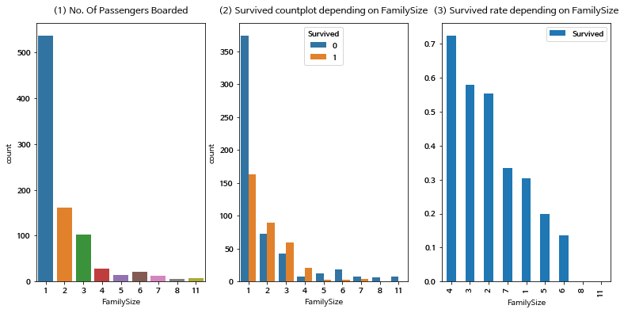

```python
f,ax=plt.subplots(1, 3, figsize=(13,6))
sns.countplot('FamilySize', data=train, ax=ax[0])
ax[0].set_title('(1) No. Of Passengers Boarded', y=1.02)

sns.countplot('FamilySize', hue='Survived', data=train, ax=ax[1])
ax[1].set_title('(2) Survived countplot depending on FamilySize',  y=1.02)

train[['FamilySize', 'Survived']].groupby(['FamilySize'], as_index=True).mean().sort_values(by='Survived', ascending=False).plot.bar(ax=ax[2])
ax[2].set_title('(3) Survived rate depending on FamilySize',  y=1.02)

plt.subplots_adjust(wspace=0.2, hspace=0.5)
plt.show()
```

- (1) : 가족수는 대부분 1명이고, 그 다음으로 2, 3, 4명이다.
- (2), (3) : 가족수는 2~4명일때 가장 높았으며, 너무 많거나(5, 6, 7, 8, 11) 너무 적은 경우(1) 생존확률이 낮다..

### 3.8) Fare

- Fare는 탑승요금이며, 연속형 변수에 속한다.
- 히스토그램을 그리면 다음과 같다.

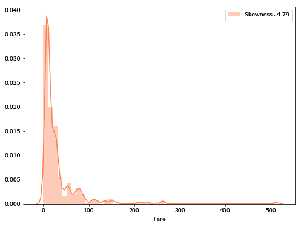

```python
fig, ax = plt.subplots(1, 1, figsize=(8, 6))
g = sns.distplot(train['Fare'], color='coral', label='Skewness : {:.2f}'.format(train['Fare'].skew()), ax=ax)
g = g.legend(loc='best')
```

- Fare의 분포는 매우 비대칭으로 가격이 낮은 경우가 대다수이다.
- 이를 모델에 그대로 적용한다면, 학습이 왜곡될 수 있는 위험이 있다.
- 따라서 큰 값의 영향을 줄이기 위해 로그를 취한다.

```python
test.loc[test.Fare.isnull(), 'Fare'] = test['Fare'].mean() # testset 에 있는 nan value 를 평균값으로 치환합니다.

train['Fare'] = train['Fare'].map(lambda i: np.log(i) if i > 0 else 0) # 0보다 큰 값은 로그, 아니면 0
test['Fare'] = test['Fare'].map(lambda i: np.log(i) if i > 0 else 0)
```

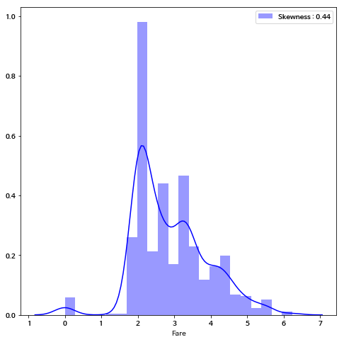

```python
fig, ax = plt.subplots(1, 1, figsize=(8, 8))
g = sns.distplot(train['Fare'], color='b', label='Skewness : {:.2f}'.format(train['Fare'].skew()), ax=ax)
g = g.legend(loc='best')
```

- fare 변수가 로그를 취한 후 비대칭성이 많이 사라짐을 볼 수 있고, 이렇게 feature engineering를 한 후 모델에 적용한다.

### 3.9) Cabin

- Cabin은 결측치가 대부분이므로, 생존에 영향을 미칠 중요한 정보인지 알기가 쉽지 않다. 따라서 당장은 모델에 포함하지 않고 진행한다.

```python
train = train.drop("Cabin", axis=1)
test = test.drop("Cabin", axis=1)
```

### 3.10) Ticket

- ticket은 결측치가 존재하지 않으나, 전처리가 필요한 부분이므로 당장은 모델에 포함하지 않고 진행한다.

```python
train = train.drop("Ticket", axis=1)
test = test.drop("Ticket", axis=1)
```

### 3.11) Name

- name 또한 결측치가 존재하지 않으나, 다양한 시도를 하듯 title을 추출하지만, 당장은 모델에 적용하지 않고 진행한다.

```python
train = train.drop("Name", axis=1)
test = test.drop("Name", axis=1)
```

## 4. Feature engineering

- 이 과정은 변수들의 결측치를 처리해주고, 새로운 변수를 생성하는 것 등 실제 모델의 학습에 사용되어야 하므로, 훈련셋 뿐만 아니라 테스트셋에도 똑같이 적용해야 한다.

### 4.1) 결측치 처리 : age

- age에는 결측치가 177개가 존재한다.
- 결측치를 처리하는 방법은 여러가지가 존재하지만, 첫 번째 시도에서는 나이의 평균값으로 대체하고 모델에 적용해보고자 한다.

```python
train_m_age = train['Age'].mean()
test_m_age = test['Age'].mean()
```

```python
train['Age'].fillna(train_m_age, inplace=True)
test['Age'].fillna(test_m_age, inplace=True)
```

### 4.2) 결측치 처리 및 숫자변환 : embarked

```python
train["Embarked"].isnull().sum() # 결측치 2개
train["Embarked"].fillna("S", inplace=True)
```

```python
train['Embarked'] = train['Embarked'].map({'C': 0, 'Q': 1, 'S': 2})
test['Embarked'] = test['Embarked'].map({'C': 0, 'Q': 1, 'S': 2})
```

```python
train['Sex'] = train['Sex'].map({'female': 0, 'male': 1})
test['Sex'] = test['Sex'].map({'female': 0, 'male': 1})
```

```python
train.head(2)
```

|  | PassengerId | Survived | Pclass | Sex | Age | SibSp | Parch | Fare | Embarked | FamilySize |
| --- | --- | --- | --- | --- | --- | --- | --- | --- | --- | --- |
| 0 | 1 | 0 | 3 | 1 | 22.0 | 1 | 0 | 1.981001 | 2 | 2 |
| 1 | 2 | 1 | 1 | 0 | 38.0 | 1 | 0 | 4.266662 | 0 | 2 |

## 5. 각 변수들간 상관관계 확인

- 상관관계는 -1에 가까울수록 음의 상관관계
- 1에 가까울수록 양의 상관관계를 갖는다.
- 0은 상관관계가 없음을 나타낸다.

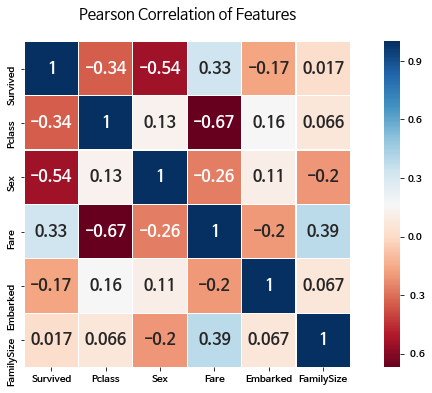

```python
heatmap_data = train[['Survived', 'Pclass', 'Sex', 'Fare', 'Embarked', 'FamilySize']]

colormap = plt.cm.RdBu
plt.figure(figsize=(12, 6))
plt.title('Pearson Correlation of Features', y=1.05, size=15)
sns.heatmap(heatmap_data.astype(float).corr(), linewidths=0.1, vmax=1.0,
           square=True, cmap=colormap, linecolor='white', annot=True, annot_kws={"size": 16})

del heatmap_data
```

- survived와 양의 상관관계를 갖는 변수는 fare가 있으며, 상관관계가 가장 큰 변수는 sex
- 상관관계가 특별하게 큰 변수가 없는 것으로 보아 모델을 학습시킬 때, 불필요한(너무 음의 관계가 강하거나, 양의관계가 강하거나) 변수가 없는 것으로 판단하고 진행

## 6. One-hot encoding (더미변수 생성)

- 수치화 시킨 범주형 데이터를 그대로 넣어도 되지만, 모델의 성능을 높이기 위해 one-hot encoding을 할 수 있다.
- pandas의 get_dummies를 사용
- embarked는 총 3개의 범주가 있으므로, 결과는 3개의 새로운 컬럼이 생성된다.

```python
train = pd.get_dummies(train, columns=["Embarked"], prefix="Embarked")
test = pd.get_dummies(test, columns=["Embarked"], prefix="Embarked")
```

## 7. 불필요한 컬럼 삭제

```python
train.head()
```

|  | PassengerId | Survived | Pclass | Sex | Age | SibSp | Parch | Fare | FamilySize | Embarked_0 | Embarked_1 | Embarked_2 |
| --- | --- | --- | --- | --- | --- | --- | --- | --- | --- | --- | --- | --- |
| 0 | 1 | 0 | 3 | 1 | 22.0 | 1 | 0 | 1.981001 | 2 | 0 | 0 | 1 |
| 1 | 2 | 1 | 1 | 0 | 38.0 | 1 | 0 | 4.266662 | 2 | 1 | 0 | 0 |
| 2 | 3 | 1 | 3 | 0 | 26.0 | 0 | 0 | 2.070022 | 1 | 0 | 0 | 1 |
| 3 | 4 | 1 | 1 | 0 | 35.0 | 1 | 0 | 3.972177 | 2 | 0 | 0 | 1 |
| 4 | 5 | 0 | 3 | 1 | 35.0 | 0 | 0 | 2.085672 | 1 | 0 | 0 | 1 |

```python
train.drop(['PassengerId','SibSp', 'Parch'], axis=1, inplace=True)
test.drop(['PassengerId','SibSp', 'Parch'], axis=1, inplace=True)
```

## 8. 머신러닝 알고리즘 적용

- 타이타닉 생존자 예측 문제는 target class(survived)가 있으며, target class는 0, 1로 이루어져 있으므로 binary classfication 문제다.
- 먼저 훈련셋의 survived를 제외한 input을 통해 모델을 학습시킨다.
- 그 후 테스트셋을 input으로 주어서 탑승객의 생존유무를 예측한다.
- 여러가지 머신러닝 알고리즘을 적용해보고, 과적합을 방지하고, 파라미터 튜닝을 통해 모델을 최적의 상태로 만들어야 하지만, 당장은 머신러닝 알고리즘만 적용해보기로 한다.

```python
from sklearn.ensemble import RandomForestClassifier # 분류 목적의 랜덤포레스트
from sklearn import metrics # 모델의 평가를 위해 사용
from sklearn.model_selection import train_test_split
```

### 8.1) 데이터셋 분리 | 7 : 3

```python
X_train = train.drop('Survived', axis=1).values
target_label = train['Survived'].values
X_test = test.values
```

```python
X_tr, X_vld, Y_tr, Y_vld  = train_test_split(X_train, target_label, test_size=0.3, random_state=2018)
```

### 8.2) 모델 생성 및 검증

```python
model = RandomForestClassifier()
model.fit(X_tr, Y_tr)
prediction = model.predict(X_vld)
```

```python
print('총 {}명 중 {:.2f}% 정확도로 생존을 맞춤'.format(Y_vld.shape[0], 100 * metrics.accuracy_score(prediction, Y_vld)))
```

```
총 268명 중 85.45% 정확도로 생존을 맞춤
```

### 8.3) 모델에 영향을 주는 변수 확인

- 학습된 모델은 feature importance를 갖게 되는데, 이를 확인해 지금 만든 모델이 어떤 feature에 영향을 많이 받았는지 확인할 수 있다.
- pandas series를 이용하면 쉽게 정렬하여 그래프를 그릴 수 있다.

```python
from pandas import Series

feature_importance = model.feature_importances_
Series_feat_imp = Series(feature_importance, index=test.columns)
```

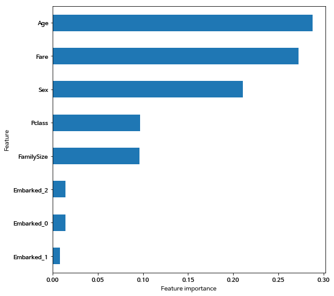

```python
plt.figure(figsize=(8, 8))
Series_feat_imp.sort_values(ascending=True).plot.barh()
plt.xlabel('Feature importance')
plt.ylabel('Feature')
plt.show()
```

- 위 모델에서는 age, fare, sex ... 순으로 큰 영향력을 가지는 것으로 나타났다.
- 사실 feature importance는 지금 모델에서의 importance를 나타낸다.
- 만약 다른 모델을 사용할 경우 feature importance는 결과가 다르게 나올 수 있다.
- 이 feature importance 를 보고 실제로 Fare 가 중요한 feature 일 수 있다고 판단을 내릴 수는 있지만, 이것은 결국 모델에 귀속되는 하나의 결론이므로 통계적으로 좀 더 살펴보긴 해야한다.
- featuure importance 를 가지고 좀 더 정확도가 높은 모델을 얻기 위해 feature selection 을 할 수도 있고, 좀 더 빠른 모델을 위해 feature 제거를 할 수 있다.

### 8.4) 모델 평가

- 모델이 학습하지 않았던 테스트셋으로 만들어진 모델에 적용하여 생존여부를 예측한 후 캐글에 제출해본다.

```python
submission = pd.read_csv(path+'/sample_submission.csv')
```

```python
submission.head()
```

|  | PassengerId | Survived |
| --- | --- | --- |
| 0 | 892 | 0 |
| 1 | 893 | 0 |
| 2 | 894 | 0 |
| 3 | 895 | 0 |
| 4 | 896 | 0 |

```python
prediction = model.predict(X_test)
submission['Survived'] = prediction
```

```python
submission.to_csv(path+'./my_first_submission.csv', index=False)
```

## 9. 마무리

- 검증에서의 예측률은 85.5%가 나왔지만, submission 제출 결과 71%의 정확률이 나타났다. 즉, 모델의 과적합이 발생했다.
- 따라서 모델의 과적합을 방지할 수 있는 방법을 적용할 필요가 있다.
- 또한 각 feature의 전처리 과정을 다시 한번 살펴볼 필요가 있다. 예를들어 나이의 결측치를 전체의 평균으로 대치했지만, 다른 방법을 적용해볼 필요가 있다.
- 그 외에 다양한 모델 적용과 파라미터 튜닝이 필요하다.